# Convergence in 𝘩 with rough forcing

Last modified: 29-10-2026.

Go back to the Contents page.

# 1 Problem and exact solution

On the tadpole graph with stem length $1$ and loop length $2$, let $L=\kappa^2-\Delta_\Gamma$ and consider
$$\partial_tu+\nu L^{\alpha/2}u=g,\qquad u(0)=0,
\qquad T=1,\quad\nu=1,\quad\kappa=4.$$
Use the same forcing for every $\alpha$:
$$g=\sum_{j=1}^{\infty}\frac1j\phi_j,
\qquad
\phi_j(s)=
\begin{cases}
0,&s\text{ on the stem},\\
\sin(2^j\pi x),&s=x\in[0,2]\text{ on the loop}.
\end{cases}$$
These orthonormal Kirchhoff eigenfunctions have eigenvalues $\mu_j=\kappa^2+\pi^2 2^{2j}$. The series defines an $L_2(\Gamma)$ forcing: $\|g\|_{L_2(\Gamma)}^2=\sum_{j\geq1}j^{-2}<\infty$. For every $s>0$, $\sum_{j\geq1}\mu_j^s/j^2=\infty$, so $g$ has no positive spectral Sobolev regularity. Writing $a_j=\nu\mu_j^{\alpha/2}$ gives the exact solution
$$u(s,t)=\sum_{j=1}^{\infty}\frac{1-e^{-a_jt}}{j\,a_j}\phi_j(s).$$

Theorem `lastlasttheorem` in `main.tex` gives the spatial term $h^{\alpha-\epsilon}$ because $s_f=0$ and $u_0=0$ belongs to every spectral Sobolev space. For this particular forcing, uniform P1 meshes with $h_J=2^{-J}$ give the sharper asymptotic behavior
$$E_{h_J}:=\|u-U_{h_J,m}^{\tau}\|_{L_2(0,T;L_2(\Gamma))}
\asymp\frac{h_J^\alpha}{J},\qquad0<\alpha<2,$$
when temporal and rational errors are negligible. Thus the raw slope tends to $\alpha$; plotting $J E_{h_J}$ removes the leading logarithmic factor.

# 2 Matrix discretization and error

The consistent P1 mass and stiffness matrices are assembled on the tadpole with `MetricGraph`. Every backward Euler step advances the FEM coefficient vector by shifted sparse matrix solves, using the same matrix update as `cov_in_h_mat.Rmd`. The rational inverse is obtained from the positive BRASIL coefficients in `rSPDE`, with order $m=14$. The constant term of this approximant is included in the update. The factorizations are reused across all time steps.

The forcing is supported on the loop and has exact reflection symmetries. The shifted FEM matrices are restricted to that invariant nodal subspace, and the full graph solution is recovered by signed reflections. This is the same FEM matrix evolution; no discrete eigenfunction recurrence is used.

The load is assembled by analytic sine–hat integrals. On a mesh $h_J=2^{-J}$, the modes $j\geq J$ have zero $L_2$ projection onto $V_{h_J}$. They remain part of the exact solution and its error. Their squared contribution is
$$E_{\mathrm{tail}}^2=
\sum_{j=J}^{\infty}\frac1{j^2a_j^2}
\left[T-\frac{2(1-e^{-a_jT})}{a_j}
+\frac{1-e^{-2a_jT}}{2a_j}\right].$$
The omitted remainder of this infinite sum is bounded by a geometric series and is at most $10^{-13}$ of its accumulated value. For the resolved modes, the FEM mass norm, the spatial projection residual, and exact time moments evaluate the error of the right-constant reconstruction on each solver interval. No reference-mesh sampling or finite-mode replacement of $g$ is used.

```r
J_vector <- p$J
h_vector <- 2^-J_vector
alpha_vector <- seq(0.5, 1.9, 0.2)
stopifnot(isTRUE(all.equal(alpha_vector, p$alpha)))
m_fixed <- p$rational_order
time_steps <- p$time_steps
T_final <- p$T_final
diffusion <- p$diffusion
kappa <- p$kappa
```

The time step and rational order are fixed along each spatial refinement curve. The final settings are:

| $\alpha$ | $\tau$ | $m$ | $h$ |
| --- | --- | --- | --- |
| 0.5 | 5.000000e-04 | 14 | 1/32, 1/64, 1/128, 1/256, 1/512 |
| 0.7 | 1.250000e-04 | 14 | 1/32, 1/64, 1/128, 1/256, 1/512 |
| 0.9 | 3.333333e-05 | 14 | 1/32, 1/64, 1/128, 1/256, 1/512 |
| 1.1 | 1.000000e-05 | 14 | 1/32, 1/64, 1/128, 1/256, 1/512 |
| 1.3 | 3.125000e-06 | 14 | 1/32, 1/64, 1/128, 1/256, 1/512 |
| 1.5 | 1.000000e-06 | 14 | 1/32, 1/64, 1/128, 1/256, 1/512 |
| 1.7 | 4.000000e-07 | 14 | 1/32, 1/64, 1/128, 1/256, 1/512 |
| 1.9 | 2.000000e-07 | 14 | 1/32, 1/64, 1/128, 1/256, 1/512 |

# 3 Results

The solid curves show the computed matrix-solver errors. Dashed curves in the first figure follow $C_\alpha h^\alpha/J$; dashed curves in the second follow $C_\alpha h^\alpha$. Their constants are fitted over the three finest meshes, $h=1/128,1/256,1/512$.

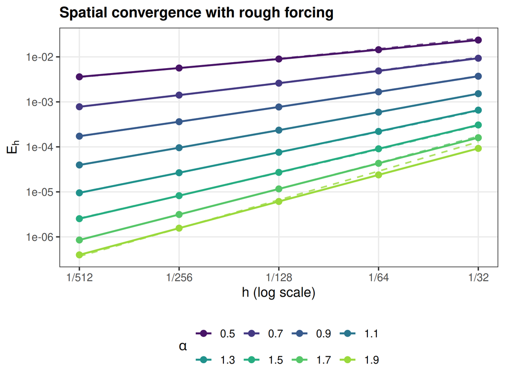

Spatial error for the fixed rough forcing. Dashed curves follow h^alpha/J; solid curves and markers are the matrix-solver results.

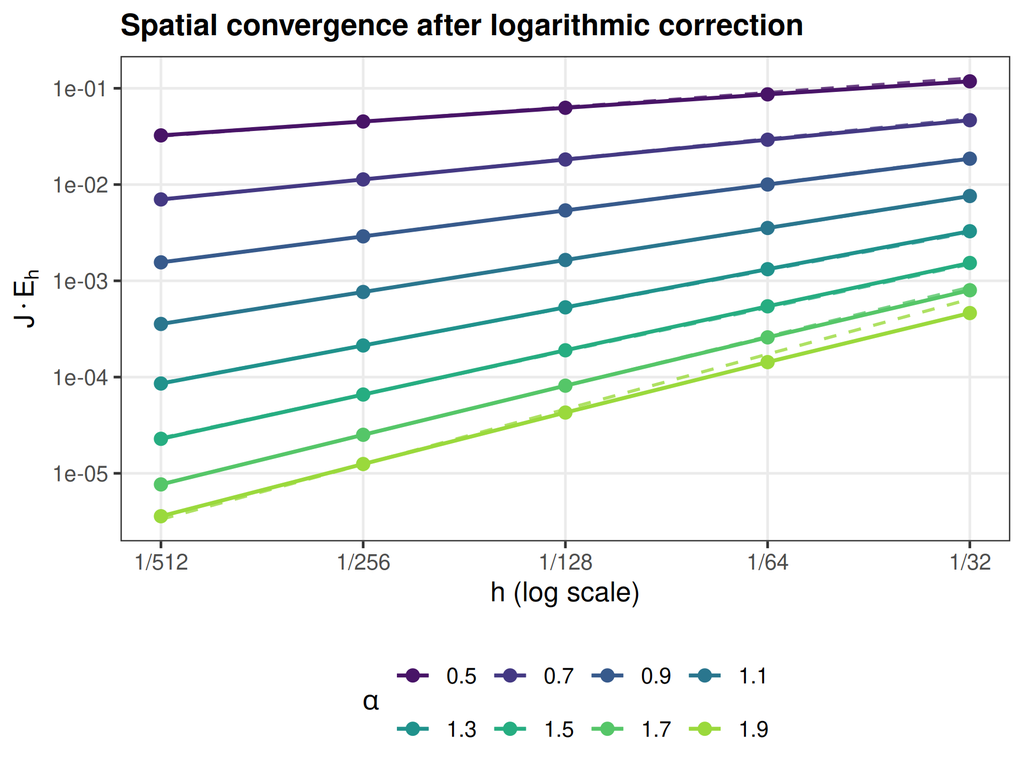

Logarithmically corrected error J E_h, where J=log_2(1/h). Dashed lines have slope alpha.

Regression slopes over the three finest meshes.

| $\alpha$ | Reference | Raw slope | Corrected slope | Corrected relative error (%) |
| --- | --- | --- | --- | --- |
| 0.5 | 0.5 | 0.6576 | 0.4763 | 4.73 |
| 0.7 | 0.7 | 0.8703 | 0.6890 | 1.58 |
| 0.9 | 0.9 | 1.0776 | 0.8963 | 0.41 |
| 1.1 | 1.1 | 1.2848 | 1.1035 | 0.32 |
| 1.3 | 1.3 | 1.4959 | 1.3146 | 1.12 |
| 1.5 | 1.5 | 1.7088 | 1.5275 | 1.84 |
| 1.7 | 1.7 | 1.8850 | 1.7037 | 0.22 |
| 1.9 | 1.9 | 1.9700 | 1.7887 | 5.86 |

The logarithmic correction accounts for the factor $1/J$ in the error model. The remaining differences from $\alpha$ reflect the finite refinement range: $J E_h\sim C_\alpha h^\alpha$ is an asymptotic statement. For $\alpha$ close to $2$, the second-order contribution from low modes can remain significant over this mesh range, so the limiting corrected slope can take longer to appear.

Computed space–time errors.

| $h$ | $\alpha=0.5$ | $\alpha=0.7$ | $\alpha=0.9$ | $\alpha=1.1$ | $\alpha=1.3$ | $\alpha=1.5$ | $\alpha=1.7$ | $\alpha=1.9$ |
| --- | --- | --- | --- | --- | --- | --- | --- | --- |
| 1/32 | 2.362798e-02 | 9.325537e-03 | 3.712510e-03 | 1.520247e-03 | 6.551629e-04 | 3.064913e-04 | 1.597036e-04 | 9.249039e-05 |
| 1/64 | 1.441951e-02 | 4.871006e-03 | 1.669507e-03 | 5.899297e-04 | 2.201467e-04 | 9.057570e-05 | 4.310078e-05 | 2.384279e-05 |
| 1/128 | 8.962110e-03 | 2.601674e-03 | 7.699477e-04 | 2.350820e-04 | 7.574622e-05 | 2.711481e-05 | 1.162858e-05 | 6.114010e-06 |
| 1/256 | 5.649129e-03 | 1.413564e-03 | 3.620268e-04 | 9.567533e-05 | 2.661525e-05 | 8.233109e-06 | 3.142424e-06 | 1.562114e-06 |
| 1/512 | 3.601524e-03 | 7.785923e-04 | 1.728487e-04 | 3.960069e-05 | 9.522640e-06 | 2.537455e-06 | 8.523748e-07 | 3.983382e-07 |